# Kreisfläche

## Der Kreisfläche auf der Spur - ein Versuchsaufbau

Der folgende “mathematische Versuchsaufbau” soll dir helfen, die Formel für den Flächeninhalt des Kreises herzuleiten und zu verstehen. Probiere also aus, was passiert, wenn du an den gegebenen “Stellschrauben drehst” (also die Schieberegler bedienst).

[interactive chart not shown]

Solltest du Schwierigkeiten bei der Beantwortung der beiden Fragen aus dem “Versuchsaufbau” haben, gibt es hier noch drei Tipps:

Erhöht man die Anzahl der Kreisteile immer mehr, nähert sich die neu angeordnete Fläche einem Rechteck an. Was sind Länge und Breite dieses Rechtecks?

Die Breite des Rechtecks kann man im “Versuchsaufbau” ablesen. Sie entspricht dem Radius $r$ des Kreises. Die Länge des Rechteck muss der halbe Kreisumfang sein. Warum?

Setze die gefundenen Größen:

- Breite des Rechtecks: $r$ und
- Länge des Rechtecks: ${1 \over 2} \cdot U = {1 \over 2} \pi \cdot 2r$

in die Formel zur Berechung des Flächeninhaltes eines Rechtecks ein und vereinfache diese.

## Versuchsprotokoll

Zunächst zerteilt man den Kreis in gleich große (Kuchen-) Stücke.

Diese ordnet man neu an: Man legt sie so nebeneinander, so dass sie eine annähernd parallelogrammförmige Fläche ergeben. Je größer die Anzahl der Kreisteile wird, desto mehr nähert sich die Fläche einem Rechteck an. Würde man den Kreis in unendlich viele Teile zerschneiden, ergäbe sich schließlich tatsächlich ein Rechteck.

Den Flächeninhalt dieses Rechtecks kann man nun mit der bekannten Formel $A=l \cdot b$ berechnen. Die Breite des Rechtecks entspricht dabei dem Radius $r$, seine Länge dem halben Kreisumfang ${1 \over 2} \cdot U= \pi \cdot r$.

## Ergebnis

Damit ergibt sich für die Kreisfläche folgende Formel zur Berechnung des Flächeninhaltes:

$$\begin{align} A &= Länge \cdot Breite\\
{}\\
A &= {1 \over 2} \cdot U \cdot r\\
{}\\
A & ={1 \over 2} \cdot \pi \cdot 2 \cdot r \cdot r\\
{}\\
A & = {1 \over 2} \cdot 2 \cdot \pi \cdot r²\\
{}\\
A &= \pi \cdot r²
\end{align}$$

Für den Flächeninhalt eines Kreises gilt also: $\quad A= \pi \cdot r²$

### Aufgaben

Hier geht es zurück zur Übersichtsseite [**Kreis**](https://gdischinger.github.io/Mathe_8a/03FormelnErstellen/Kreis.html).

Hier geht es zurück zur [**Startseite**](https://gdischinger.github.io/Mathe_8a/03FormelnErstellen/FlächenberechnungErinnerung.html).

#### Aufgabe 1

Berechne die fehlenden Größen.

|  | a) | b) | c) |
| --- | --- | --- | --- |
| Radius $r$ |  |  |  |
| Durchmesser $d$ |  |  | $7,543m$ |
| Umfang $U$ |  | $1,543km$ |  |
| Flächeninhalt $A$ | $13cm²$ |  |  |

**Die fehlenden Größen lauten:**

|  | a) | b) | c) |
| --- | --- | --- | --- |
| Radius $r$ | $2,034 cm$ | $0,246 km$ | $3,772 m$ |
| Durchmesser $d$ | $4,068 cm$ | $0,491 km$ | $7,543m$ |
| Umfang $U$ | $12,78 cm$ | $1,543km$ | $23,70 m$ |
| Flächeninhalt $A$ | $13cm²$ | $0,189 km²$ | $44,69 m²$ |

**Rechnungen:**

**a)**

**Radius**

$A = \pi \cdot r²$ nach $r$ auflösen:

$$\begin{align} A &= \pi \cdot r² \quad |:\pi \\
{}\\
{A \over \pi} &= r² \quad |\sqrt{\quad}\\
{}\\
\sqrt{A \over \pi} &= r
\end{align}$$

$A=13cm²$ einsetzen:

$$r = \sqrt{13 cm² \over \pi} \approx 2,034 cm$$

**Durchmesser**

$d=2 \cdot r \approx 2 \cdot 2,034 cm \approx 4,068 cm$

**Umfang**

$U = \pi \cdot d \approx \pi \cdot 4,068 cm \approx 12,78 cm$

**b)**

**Durchmesser**

Auflösen ergibt:

$$\begin{align} U &= \pi \cdot d \quad\quad |: \pi \\
{}\\
{U \over \pi} &= d
\end{align}$$
.

$U=1,543 km$ einsetzen:

$$d={1,543 km \over \pi} \approx 0,491 km$$

**Radius**

$d = 2 \cdot r$ nach $r$ auflösen:

$$\begin{align} d &=2 \cdot r \quad |:2\\
{}\\
{d \over 2} &= r
\end{align}$$

$0,491 km$ einsetzen:

$$r \approx {0,491 km \over 2} \approx 0,246 km$$

**Flächeninhalt**

$A = \pi \cdot r² \approx \pi \cdot (0,246 km)² \approx 0,189 km²$

**c)**

**Umfang**

$U = \pi \cdot d = \pi \cdot 7,543 m \approx 23,70 m$

**Radius**

$d = 2 \cdot r$ nach $r$ auflösen:

$$\begin{align} d &=2 \cdot r \quad |:2\\
{}\\
{d \over 2} &= r
\end{align}$$

$7,543 m$ einsetzen:

$$r = {7,543 m \over 2} \approx 3,772 m$$

**Flächeninhalt**

$A = \pi \cdot r² \approx \pi \cdot (3,772 m)² \approx 44,69 m²$

Hier geht es zurück zur Übersichtsseite [**Kreis**](https://gdischinger.github.io/Mathe_8a/03FormelnErstellen/Kreis.html).

Hier geht es zurück zur [**Startseite**](https://gdischinger.github.io/Mathe_8a/03FormelnErstellen/FlächenberechnungErinnerung.html).

#### Aufgabe 2

In einer Pizzeria gibt es Pizzen in zwei Größen. Die kleine Pizza hat einen Durchmesser von $25cm$. Die Fläche der großen Pizza ist doppelt so groß wie die der kleinen Pizza. Berechne den Durchmesser der großen Pizza.

**Gegeben**

- Die kleine Pizza hat den Durchmesser $d_{klein} = 25 cm$.
- Die Fläche der großen Pizza ist doppelt so groß wie die der kleinen Pizza, also: $A_{groß}= 2 \cdot A_{klein}$

**Gesucht**

Der Durchmesser der großen Pizza.

**Vorgehen**

$\quad \rightarrow \quad$ Radius der kleinen Pizza ermitteln $\quad \rightarrow \quad$ Flächeninhalt der kleinen Pizza berechnen $\quad \rightarrow \quad$ Flächeninhalt der großen Pizza ermitteln $\quad \rightarrow \quad$ Radius der großen Pizza ermitteln $\quad \rightarrow \quad$ Durchmesser der großen Pizza berechnen

**Radius der kleinen Pizza**

$$r_{klein} = {d_{klein} \over 2} = {25 cm \over 2} = 12,5 cm$$

**Flächeninhalt der kleinen Pizza**

$$A_{klein}= \pi \cdot r^2_{klein} = \pi \cdot (12,5cm)² \approx 490,87 cm²$$

**Flächeninhalt der großen Pizza**

$$A_{groß} = 2 \cdot A_{klein} \approx 981,74 cm²$$

**Radius der großen Pizza**

$$r_{groß}= \sqrt{A_{groß} \over \pi} \approx \sqrt{312,5cm²} \approx 17,68 cm$$

**Durchmesser der großen Pizza**

$$d_{groß}= 2 \cdot r_{groß} \approx 35,36 cm$$

Hier geht es zurück zur Übersichtsseite [**Kreis**](https://gdischinger.github.io/Mathe_8a/03FormelnErstellen/Kreis.html).

Hier geht es zurück zur [**Startseite**](https://gdischinger.github.io/Mathe_8a/03FormelnErstellen/FlächenberechnungErinnerung.html).

#### Aufgabe 3

Untersuche an Zahlenbeispielen und begründe dann allgemein.

1. Wie verändert sich der Umfang bzw. der Flächeninhalt eines Kreises, wenn sich der Radius verdoppelt?
2. Wie verändert sich der Umfang bzw. der Flächeninhalt eines Kreises, wenn man den Radius um $10cm$ vergrößert?

**a)**

**Umfang**

Für den Umfang eines Kreises gilt: $U = 2 \cdot \pi \cdot r$.

Verdoppelt man den Radius (beispielsweise von $3cm$ auf $2 \cdot 3cm =6cm$), setzt man also statt des Radiuses $r$ den Radius $2 \cdot r$ in die Formel für den Umfang ein.

Damit erhält man
$$\begin{align} U_{neu} &= 2 \cdot \pi \cdot (2 \cdot r)= \\
{}\\
&= 2 \cdot \underbrace{2 \cdot \pi \cdot r}_{= U} =\\
{}\\
&= 2 \cdot U \end{align}$$

Bei doppeltem Radius verdoppelt sich also der Umfang.

**Flächeninhalt**

Für den Flächeninhalt eines Kreises gilt: $A= \pi \cdot r^2$.

Damit erhält man

$$\begin{align} A_{neu} &= \pi \cdot (2r)^2 =\\
{}\\
&= \pi \cdot 4\cdot r^2 =\\
{}\\
&= 4 \cdot \underbrace{\pi \cdot r^2}_{=A} =\\
{}\\
&= 4 \cdot A \end{align}$$

Bei doppeltem Radius vervierfacht sich also der Flächeninhalt.

**b)**

**Umfang**

Für den Umfang eines Kreises gilt: $U = 2 \cdot \pi \cdot r$.

Vergrößert man den Radius eines Kreises um $10cm$ (z.B. von $6cm$ auf $16cm$), bedeutet dies, dass man in die Formel für den Umfang eines Kreises statt des Radiuses $r$ den Radius $r+10cm$ einsetzt.

Damit erhält man

$$\begin{align} U_{neu} &= 2 \cdot \pi \cdot (r + 10cm) =\\
{}\\
&= \underbrace{2 \cdot \pi \cdot r}_{=U} + 2 \cdot \pi \cdot 10cm =\\
{}\\
&= U + 20\cdot\pi cm \end{align}$$

Erhöht man den Radius um $10cm$, erhöht sich der Umfang um $20 \cdot \pi cm$.

**Flächeninhalt**

Für den Flächeninhalt eines Kreises gilt: $A= \pi \cdot r^2$.

Vergrößert man den Radius eines Kreises um $10cm$ (z.B. von $6cm$ auf $16cm$), bedeutet dies, dass man in die Formel für den Flächeninhalt eines Kreises statt des Radiuses $r$ den Radius $r+10cm$ einsetzt.

Damit erhält man

$$\begin{align} A_{neu} &= \pi \cdot (r+10)^2 =\\
{}\\
&= \pi \cdot (r^2+2\cdot r \cdot 10 + 100) =\\
{}\\
&= \pi \cdot (r^2+ r \cdot 20 + 100) =\\
{}\\
&= \underbrace{\pi \cdot r^2}_{=A} + \pi \cdot r \cdot 20 + \pi \cdot 100 =\\
{}\\
&= A + 20 \pi \cdot (r+5) \end{align}$$

Erhöht man den Radius um $10cm$, erhöht sich der Flächeninhalt um $20 \pi \cdot (r+5)cm²$.

Hier geht es zurück zur Übersichtsseite [**Kreis**](https://gdischinger.github.io/Mathe_8a/03FormelnErstellen/Kreis.html).

Hier geht es zurück zur [**Startseite**](https://gdischinger.github.io/Mathe_8a/03FormelnErstellen/FlächenberechnungErinnerung.html).

#### Aufgabe 4

Ein kreisrunder Froschteich hat den Radius $r_1=7m$.

1. Um den Teich wird ein 3m breiter Weg angelegt. Welchen Flächeninhalt hat der Weg.
2. Wie breit ist der Weg, wenn er einen Flächeninhalt von $130 m²$ hat?

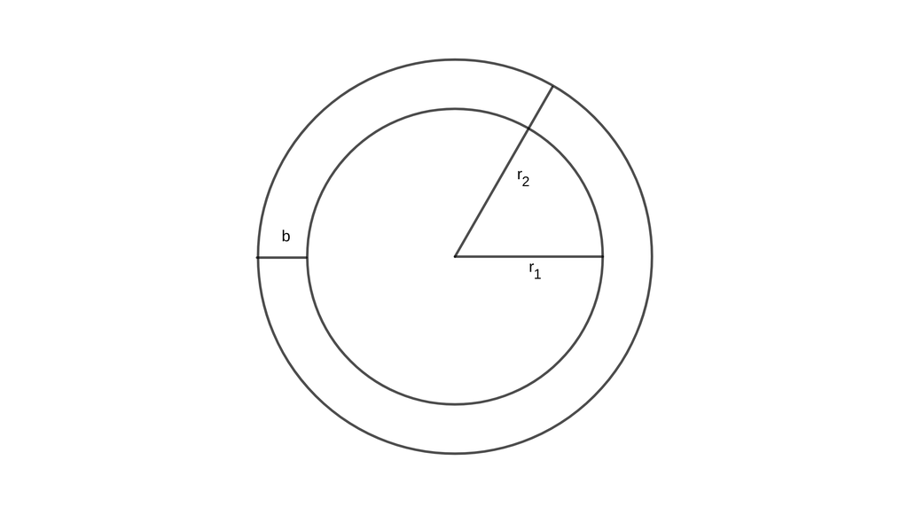

**a)**

**Gegeben**

- Der kleinere Kreis $k_1$ hat den Radius $r_1 = 7m$.
- Die Breite $b$ des Weges beträgt $3m$. Damit hat der größere Kreis $k_2$ den Radius $r_2= 10m$.

**Vorüberlegung**

Zieht man den Flächeninhalt des kleineren Kreises vom Flächeninhalt des größeren Kreises ab, bleibt der Flächeninhalt des Weges übrig. Es gilt also:

$$A_{Weg}=A_{k_2} - A_{k_1}$$

Den Flächeninhalt eines Kreises berechnet man mit der Formel: $A=\pi \cdot r^2$

**Aufstellen der Formel zur Berechnung des Flächeninhaltes des Weges**

$$\begin{align} A_{Weg} &=A_{k_2} - A_{k_1} =\\
&= \pi \cdot r^2_2 - \pi \cdot r^2_1 =\\
&= \pi \cdot (r^2_2 -r^2_1) \end{align}$$

**Einsetzen**

$$\begin{align} A_{Weg} &= \pi \cdot (r^2_2 -r^2_1) =\\
&=\pi \cdot (100m² - 49m²) =\\
&= \pi \cdot 51m² \approx 160,22m² \end{align}$$

**Antwort**

Der Flächeninhalt des Weges beträgt ca. 160m².

**b)**

**Gegeben**

- Der kleinere Kreis $k_1$ hat den Radius $r_1 = 7m$.
- Der Weg hat einen Flächeninhalt von $130 m²$.

**Vorüberlegung**

Die Breite des Weges ergibt sich aus der Differenz der beiden Radien: $b=r_2 - r_1$.

$r_1$ ist gegeben, $r_2$ dagegen muss noch ermittelt werden.

Mit Hilfe des Radiuses $r_1$ des kleineren Kreises $k_1$ kann man den Flächeninhalt des kleineren Kreises berechnen: $A_1 = \pi \cdot r^2_1$. Addiert man zu dieser Fläche die Fläche des Weges $A_{Weg}$, ergibt sich der Flächeninhalt des größeren Kreises, also $A_2= A_1+ A_{Weg}$.

Hat man den Flächeninhalt des größeren Kreises, lässt sich der Radius $r_2$ des größeren Kreises bestimmen.

Für den Radius eines Kreises mit Flächeninhalt $A$ gilt: $r = \sqrt{A \over \pi}$.

**Aufstellen der Formel zur Berechnung der Breite des Weges**
$$\begin{align} b &= r_2 - r_1 = \\
{}\\
&= \sqrt{A_2 \over \pi} - r_1=\\
{}\\
&= \sqrt{A_1+ A_{Weg} \over \pi} - r_1= \\
{}\\
& = \sqrt{\pi \cdot r^2_1+ A_{Weg} \over \pi} - r_1
\end{align}$$

**Einsetzen**

$$\begin{align} b &=\sqrt{\pi \cdot r^2_1+ A_{Weg} \over \pi} - r_1=\\
{}\\
&=\sqrt{\pi \cdot (7m)²+ 130m² \over \pi} - 7m \approx\\
{}\\
& \approx \sqrt{ 283,93804 m² \over \pi} - 7m \approx \\
{}\\
& \approx \sqrt{90,3802852 m²} - 7m \approx 2,5 m \end{align}$$

**Antwort**

Der Weg ist ca.$2,5m$ breit.

Hier geht es zurück zur Übersichtsseite [**Kreis**](https://gdischinger.github.io/Mathe_8a/03FormelnErstellen/Kreis.html).

Hier geht es zurück zur [**Startseite**](https://gdischinger.github.io/Mathe_8a/03FormelnErstellen/FlächenberechnungErinnerung.html).

#### Aufgabe 5

Aus einer quadratischen Platte mit der Seitenlänge $a$ wird eine Kreisscheibe herausgeschnitten (vgl. Skizze).

1. Berechne den Verschnitt, wenn die Seite $a$ 4m lang ist.
2. Stelle eine Formel auf, mit der man den Flächeninhalt des Verschnitts in Abhängigkeit von $a$ bestimmen kann.
3. Wie viel Prozent der Gesamtfläche sind Verschnitt?

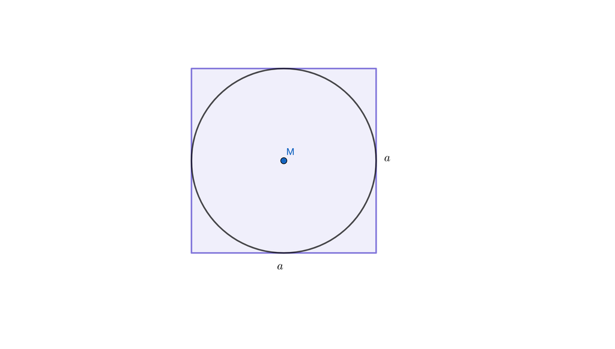

Ein Quadrat mit Seitenlänge $4m$ hat den Flächeninhalt $A_{Quadrat}=16m²$.

In diesem Fall hat der dem Quadrat einbeschriebene Kreis den Durchmesser $d=4m$ und somit den Radius $r=2m$.

Damit hat der Kreis einen Flächeninhalt von $A_{Kreis}= \pi \cdot (2m)² = 4\pi\; m²$.

Der Verschnitt ergibt sich als Differenz der Quadratfläche und der Kreisfläche:

$$\begin{align} Verschnitt &= A_{Quadrat} - A_{Kreis} =\\
{}\\
&= 16 \;m² - 4 \pi \;m² \\
{}\\
& \approx 3,43\; m^2\end{align}$$

**Vorüberlegung**

Der Verschnitt ergibt sich als Differenz der Quadratfläche und der Kreisfläche. Für die Quadratfläche gilt: $A_{Quadrat}=a²$.

Der dem Quadrat einbeschriebene Kreis hat den Durchmesser $d=a$ und damit den Radius $r= {a \over 2}$. Für seine Fläche gilt also: $A_{Kreis} = \pi \cdot ({a \over 2})^2$

**Aufstellen der Formel**
$$\begin{align} Verschnitt &= A_{Quadrat} - A_{Kreis} =\\
{}\\
&= a^2 - \pi \cdot ({a \over 2})^2 = \\
{}\\
& = a^2 - \pi \cdot {a^2 \over 4} = \\
{}\\
& = a^2 - {\pi \cdot a^2 \over 4} = \\
{}\\
& = a^2 - {\pi \over 4} \cdot a^2 =\\
{}\\
& = a^2 \cdot (1 - {\pi \over 4})
\end{align}$$

**Vorüberlegung**

Gefragt ist also, welchen Anteil der Verschnitt an der Gesamtfläche hat.

**Anteil des Verschnitts an der Gesamtfläche**

Man muss folgenden Quotienten berechnen:

$$\begin{align} Anteil &= {Verschnitt \over Quadratfläche} = \\
{}\\
&= {a^2 \cdot (1 - {\pi \over 4}) \over a^2} = \\
{}\\
&= 1- {\pi \over4} \approx 0,2146
\end{align}$$

**Antwort**

Etwa 21,5% der Fläche sind Verschnitt.

Hier geht es zurück zur Übersichtsseite [**Kreis**](https://gdischinger.github.io/Mathe_8a/03FormelnErstellen/Kreis.html).

Hier geht es zurück zur [**Startseite**](https://gdischinger.github.io/Mathe_8a/03FormelnErstellen/FlächenberechnungErinnerung.html).